# Risk Factor Analysis

## Outcome Variable

**Outcome Variable:** haz

## Predictor Variables

**Intervention Variable:** perdiar24

**Adjustment Set:**

- arm
- sex
- meducyrs
- feducyrs
- hhwealth_quart
- hfoodsec
- vagbrth
- hdlvry
- W_birthwt
- W_birthlen
- single
- W_nrooms
- month
- brthmon
- impfloor
- impsan
- safeh20
- delta_meducyrs
- delta_feducyrs
- delta_hhwealth_quart
- delta_hfoodsec
- delta_vagbrth
- delta_hdlvry
- delta_W_birthwt
- delta_W_birthlen
- delta_single
- delta_W_nrooms
- delta_month
- delta_brthmon
- delta_impfloor
- delta_impsan
- delta_safeh20

## Stratifying Variables

The analysis was stratified on these variable(s):

- agecat
- studyid
- country

## Data Summary

| agecat | studyid | country | perdiar24 | n_cell | n | outcome_variable |
| --- | --- | --- | --- | --- | --- | --- |
| Birth | CMIN | BANGLADESH | 0% | 12 | 26 | haz |
| Birth | CMIN | BANGLADESH | (0%, 5%] | 4 | 26 | haz |
| Birth | CMIN | BANGLADESH | >5% | 10 | 26 | haz |
| Birth | CONTENT | PERU | 0% | 0 | 2 | haz |
| Birth | CONTENT | PERU | (0%, 5%] | 1 | 2 | haz |
| Birth | CONTENT | PERU | >5% | 1 | 2 | haz |
| Birth | EE | PAKISTAN | 0% | 161 | 240 | haz |
| Birth | EE | PAKISTAN | (0%, 5%] | 79 | 240 | haz |
| Birth | EE | PAKISTAN | >5% | 0 | 240 | haz |
| Birth | JiVitA-4 | BANGLADESH | 0% | 76 | 2823 | haz |
| Birth | JiVitA-4 | BANGLADESH | (0%, 5%] | 2449 | 2823 | haz |
| Birth | JiVitA-4 | BANGLADESH | >5% | 298 | 2823 | haz |
| Birth | MAL-ED | BANGLADESH | 0% | 18 | 231 | haz |
| Birth | MAL-ED | BANGLADESH | (0%, 5%] | 131 | 231 | haz |
| Birth | MAL-ED | BANGLADESH | >5% | 82 | 231 | haz |
| Birth | MAL-ED | BRAZIL | 0% | 34 | 65 | haz |
| Birth | MAL-ED | BRAZIL | (0%, 5%] | 29 | 65 | haz |
| Birth | MAL-ED | BRAZIL | >5% | 2 | 65 | haz |
| Birth | MAL-ED | INDIA | 0% | 5 | 47 | haz |
| Birth | MAL-ED | INDIA | (0%, 5%] | 33 | 47 | haz |
| Birth | MAL-ED | INDIA | >5% | 9 | 47 | haz |
| Birth | MAL-ED | NEPAL | 0% | 2 | 27 | haz |
| Birth | MAL-ED | NEPAL | (0%, 5%] | 19 | 27 | haz |
| Birth | MAL-ED | NEPAL | >5% | 6 | 27 | haz |
| Birth | MAL-ED | PERU | 0% | 21 | 233 | haz |
| Birth | MAL-ED | PERU | (0%, 5%] | 89 | 233 | haz |
| Birth | MAL-ED | PERU | >5% | 123 | 233 | haz |
| Birth | MAL-ED | SOUTH AFRICA | 0% | 42 | 113 | haz |
| Birth | MAL-ED | SOUTH AFRICA | (0%, 5%] | 70 | 113 | haz |
| Birth | MAL-ED | SOUTH AFRICA | >5% | 1 | 113 | haz |

[output cut: 102 more lines]

The following strata were considered:

- agecat: 24 months, studyid: CMIN, country: BANGLADESH
- agecat: 24 months, studyid: CONTENT, country: PERU
- agecat: 24 months, studyid: EE, country: PAKISTAN
- agecat: 24 months, studyid: JiVitA-4, country: BANGLADESH
- agecat: 24 months, studyid: MAL-ED, country: BANGLADESH
- agecat: 24 months, studyid: MAL-ED, country: BRAZIL
- agecat: 24 months, studyid: MAL-ED, country: INDIA
- agecat: 24 months, studyid: MAL-ED, country: NEPAL
- agecat: 24 months, studyid: MAL-ED, country: PERU
- agecat: 24 months, studyid: MAL-ED, country: SOUTH AFRICA
- agecat: 24 months, studyid: MAL-ED, country: TANZANIA, UNITED REPUBLIC OF
- agecat: 24 months, studyid: NIH-Birth, country: BANGLADESH
- agecat: 24 months, studyid: NIH-Crypto, country: BANGLADESH
- agecat: 24 months, studyid: PROVIDE, country: BANGLADESH
- agecat: 6 months, studyid: CMIN, country: BANGLADESH
- agecat: 6 months, studyid: CONTENT, country: PERU
- agecat: 6 months, studyid: EE, country: PAKISTAN
- agecat: 6 months, studyid: Guatemala BSC, country: GUATEMALA
- agecat: 6 months, studyid: JiVitA-4, country: BANGLADESH
- agecat: 6 months, studyid: MAL-ED, country: BANGLADESH
- agecat: 6 months, studyid: MAL-ED, country: BRAZIL
- agecat: 6 months, studyid: MAL-ED, country: INDIA
- agecat: 6 months, studyid: MAL-ED, country: NEPAL
- agecat: 6 months, studyid: MAL-ED, country: PERU
- agecat: 6 months, studyid: MAL-ED, country: SOUTH AFRICA
- agecat: 6 months, studyid: MAL-ED, country: TANZANIA, UNITED REPUBLIC OF
- agecat: 6 months, studyid: NIH-Birth, country: BANGLADESH
- agecat: 6 months, studyid: NIH-Crypto, country: BANGLADESH
- agecat: 6 months, studyid: PROVIDE, country: BANGLADESH
- agecat: 6 months, studyid: SAS-FoodSuppl, country: INDIA
- agecat: Birth, studyid: CMIN, country: BANGLADESH
- agecat: Birth, studyid: CONTENT, country: PERU
- agecat: Birth, studyid: EE, country: PAKISTAN
- agecat: Birth, studyid: JiVitA-4, country: BANGLADESH
- agecat: Birth, studyid: MAL-ED, country: BANGLADESH
- agecat: Birth, studyid: MAL-ED, country: BRAZIL
- agecat: Birth, studyid: MAL-ED, country: INDIA
- agecat: Birth, studyid: MAL-ED, country: NEPAL
- agecat: Birth, studyid: MAL-ED, country: PERU
- agecat: Birth, studyid: MAL-ED, country: SOUTH AFRICA
- agecat: Birth, studyid: MAL-ED, country: TANZANIA, UNITED REPUBLIC OF
- agecat: Birth, studyid: NIH-Birth, country: BANGLADESH
- agecat: Birth, studyid: NIH-Crypto, country: BANGLADESH
- agecat: Birth, studyid: PROVIDE, country: BANGLADESH

### Dropped Strata

Some strata were dropped due to rare outcomes:

- agecat: Birth, studyid: CMIN, country: BANGLADESH
- agecat: Birth, studyid: CONTENT, country: PERU
- agecat: Birth, studyid: EE, country: PAKISTAN
- agecat: Birth, studyid: MAL-ED, country: BRAZIL
- agecat: Birth, studyid: MAL-ED, country: NEPAL
- agecat: Birth, studyid: MAL-ED, country: SOUTH AFRICA
- agecat: 6 months, studyid: CMIN, country: BANGLADESH
- agecat: 6 months, studyid: EE, country: PAKISTAN
- agecat: 6 months, studyid: MAL-ED, country: BRAZIL
- agecat: 6 months, studyid: MAL-ED, country: INDIA
- agecat: 6 months, studyid: MAL-ED, country: SOUTH AFRICA
- agecat: 24 months, studyid: CMIN, country: BANGLADESH
- agecat: 24 months, studyid: CONTENT, country: PERU
- agecat: 24 months, studyid: EE, country: PAKISTAN
- agecat: 24 months, studyid: MAL-ED, country: BRAZIL
- agecat: 24 months, studyid: MAL-ED, country: INDIA
- agecat: 24 months, studyid: MAL-ED, country: PERU
- agecat: 24 months, studyid: MAL-ED, country: SOUTH AFRICA

## Methods Detail

We’re interested in the causal parameters $E[Y_a]$ for all values of $a \in \mathcal{A}$. These parameters represent the mean outcome if, possibly contrary to fact, we intervened to set all units to have $A=a$. Under the randomization and positivity assumptions, these are identified by the statistical parameters $\psi_a=E_W[E_{Y|A,W}(Y|A=a,W)]$. In addition, we’re interested in the mean of $Y$, $E[Y]$ under no intervention (the observed mean). We will estimate these parameters by using SuperLearner to fit the relevant likelihood factors – $E_{Y|A,W}(Y|A=a,W)$ and $p(A=a|W)$, and then updating our likelihood fit using a joint TMLE.

For unadjusted analyses ($W=\{\}$), initial likelihoods were estimated using Lrnr_glm to estimate the simple $E(Y|A)$ and Lrnr_mean to estimate $p(A)$. For adjusted analyses, a small library containing Lrnr_glmnet, Lrnr_xgboost, and Lrnr_mean was used.

Having estimated these parameters, we will then use the delta method to estimate relative risks and attributable risks relative to a prespecified baseline level of $A$.

# Results Detail

## Results Plots

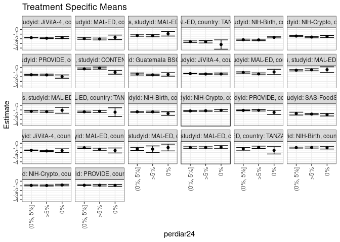

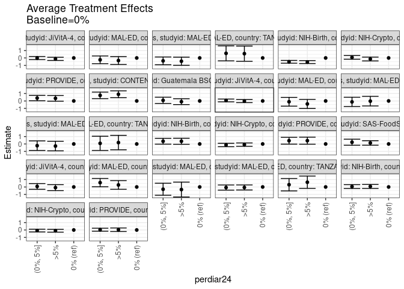

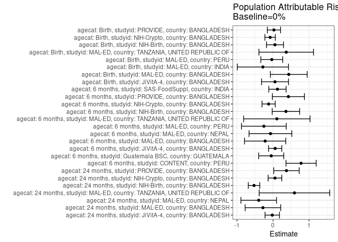

## Results Table

### Parameter: TSM

| agecat | studyid | country | intervention_level | baseline_level | estimate | ci_lower | ci_upper |
| --- | --- | --- | --- | --- | --- | --- | --- |
| Birth | JiVitA-4 | BANGLADESH | 0% | NA | -1.5782282 | -1.9585848 | -1.1978717 |
| Birth | JiVitA-4 | BANGLADESH | (0%, 5%] | NA | -1.5053663 | -1.5581825 | -1.4525501 |
| Birth | JiVitA-4 | BANGLADESH | >5% | NA | -1.6624850 | -1.7976090 | -1.5273609 |
| Birth | MAL-ED | BANGLADESH | 0% | NA | -1.5548531 | -2.0903980 | -1.0193083 |
| Birth | MAL-ED | BANGLADESH | (0%, 5%] | NA | -0.9706915 | -1.1407578 | -0.8006252 |
| Birth | MAL-ED | BANGLADESH | >5% | NA | -1.2806031 | -1.5116877 | -1.0495186 |
| Birth | MAL-ED | INDIA | 0% | NA | -0.9220000 | -1.6509223 | -0.1930777 |
| Birth | MAL-ED | INDIA | (0%, 5%] | NA | -1.2281818 | -1.5833498 | -0.8730139 |
| Birth | MAL-ED | INDIA | >5% | NA | -1.2700000 | -1.9601079 | -0.5798921 |
| Birth | MAL-ED | PERU | 0% | NA | -0.8477843 | -1.1683287 | -0.5272399 |
| Birth | MAL-ED | PERU | (0%, 5%] | NA | -0.9238254 | -1.0833518 | -0.7642990 |
| Birth | MAL-ED | PERU | >5% | NA | -0.9130755 | -1.0636035 | -0.7625475 |
| Birth | MAL-ED | TANZANIA, UNITED REPUBLIC OF | 0% | NA | -1.5222222 | -2.3091001 | -0.7353443 |
| Birth | MAL-ED | TANZANIA, UNITED REPUBLIC OF | (0%, 5%] | NA | -1.2164706 | -1.4939186 | -0.9390226 |
| Birth | MAL-ED | TANZANIA, UNITED REPUBLIC OF | >5% | NA | -0.8822581 | -1.1471959 | -0.6173203 |
| Birth | NIH-Birth | BANGLADESH | 0% | NA | -0.9854615 | -1.2377267 | -0.7331963 |
| Birth | NIH-Birth | BANGLADESH | (0%, 5%] | NA | -0.9311770 | -1.0410851 | -0.8212690 |
| Birth | NIH-Birth | BANGLADESH | >5% | NA | -0.9159070 | -1.0390515 | -0.7927626 |
| Birth | NIH-Crypto | BANGLADESH | 0% | NA | -0.8287985 | -0.9934894 | -0.6641076 |
| Birth | NIH-Crypto | BANGLADESH | (0%, 5%] | NA | -0.9079073 | -1.0107612 | -0.8050535 |
| Birth | NIH-Crypto | BANGLADESH | >5% | NA | -0.9280492 | -1.0368412 | -0.8192573 |
| Birth | PROVIDE | BANGLADESH | 0% | NA | -0.9097953 | -1.0990364 | -0.7205542 |
| Birth | PROVIDE | BANGLADESH | (0%, 5%] | NA | -0.8744484 | -0.9647162 | -0.7841806 |
| Birth | PROVIDE | BANGLADESH | >5% | NA | -0.8755588 | -1.0329956 | -0.7181219 |
| 6 months | CONTENT | PERU | 0% | NA | -1.0567500 | -1.4658384 | -0.6476616 |
| 6 months | CONTENT | PERU | (0%, 5%] | NA | -0.3029472 | -0.4697708 | -0.1361235 |
| 6 months | CONTENT | PERU | >5% | NA | -0.1570746 | -0.3744579 | 0.0603086 |
| 6 months | Guatemala BSC | GUATEMALA | 0% | NA | -1.5124001 | -1.8812398 | -1.1435603 |
| 6 months | Guatemala BSC | GUATEMALA | (0%, 5%] | NA | -1.4285752 | -1.6356581 | -1.2214924 |
| 6 months | Guatemala BSC | GUATEMALA | >5% | NA | -1.6081200 | -1.7467225 | -1.4695175 |
| 6 months | JiVitA-4 | BANGLADESH | 0% | NA | -1.4043716 | -1.5905620 | -1.2181811 |
| 6 months | JiVitA-4 | BANGLADESH | (0%, 5%] | NA | -1.3342626 | -1.3751976 | -1.2933275 |
| 6 months | JiVitA-4 | BANGLADESH | >5% | NA | -1.4198030 | -1.5109378 | -1.3286681 |
| 6 months | MAL-ED | BANGLADESH | 0% | NA | -0.9866667 | -1.5612360 | -0.4120973 |
| 6 months | MAL-ED | BANGLADESH | (0%, 5%] | NA | -1.0936385 | -1.2371707 | -0.9501063 |
| 6 months | MAL-ED | BANGLADESH | >5% | NA | -1.3891039 | -1.5904471 | -1.1877608 |
| 6 months | MAL-ED | NEPAL | 0% | NA | -0.4908904 | -1.1027731 | 0.1209923 |
| 6 months | MAL-ED | NEPAL | (0%, 5%] | NA | -0.6138600 | -0.7515130 | -0.4762070 |
| 6 months | MAL-ED | NEPAL | >5% | NA | -0.5154899 | -0.7283295 | -0.3026503 |
| 6 months | MAL-ED | PERU | 0% | NA | -1.0700000 | -1.6970711 | -0.4429289 |
| 6 months | MAL-ED | PERU | (0%, 5%] | NA | -1.3015443 | -1.4624676 | -1.1406211 |
| 6 months | MAL-ED | PERU | >5% | NA | -1.3503344 | -1.4983707 | -1.2022981 |
| 6 months | MAL-ED | TANZANIA, UNITED REPUBLIC OF | 0% | NA | -1.4750000 | -2.4233687 | -0.5266313 |
| 6 months | MAL-ED | TANZANIA, UNITED REPUBLIC OF | (0%, 5%] | NA | -1.3915631 | -1.5359143 | -1.2472119 |
| 6 months | MAL-ED | TANZANIA, UNITED REPUBLIC OF | >5% | NA | -1.2868579 | -1.5070055 | -1.0667103 |
| 6 months | NIH-Birth | BANGLADESH | 0% | NA | -1.7646922 | -2.1451127 | -1.3842717 |
| 6 months | NIH-Birth | BANGLADESH | (0%, 5%] | NA | -1.3957203 | -1.5092137 | -1.2822268 |
| 6 months | NIH-Birth | BANGLADESH | >5% | NA | -1.3997690 | -1.5465388 | -1.2529991 |
| 6 months | NIH-Crypto | BANGLADESH | 0% | NA | -1.0764190 | -1.2739416 | -0.8788964 |
| 6 months | NIH-Crypto | BANGLADESH | (0%, 5%] | NA | -1.2123180 | -1.3218351 | -1.1028010 |
| 6 months | NIH-Crypto | BANGLADESH | >5% | NA | -1.1658728 | -1.2782993 | -1.0534462 |
| 6 months | PROVIDE | BANGLADESH | 0% | NA | -1.5183235 | -1.9677946 | -1.0688524 |
| 6 months | PROVIDE | BANGLADESH | (0%, 5%] | NA | -1.0829756 | -1.1711078 | -0.9948435 |
| 6 months | PROVIDE | BANGLADESH | >5% | NA | -1.0753280 | -1.2264689 | -0.9241872 |
| 6 months | SAS-FoodSuppl | INDIA | 0% | NA | -2.0214554 | -2.2903064 | -1.7526043 |
| 6 months | SAS-FoodSuppl | INDIA | (0%, 5%] | NA | -1.7842144 | -2.0917240 | -1.4767048 |
| 6 months | SAS-FoodSuppl | INDIA | >5% | NA | -1.8861410 | -2.0228340 | -1.7494480 |
| 24 months | JiVitA-4 | BANGLADESH | 0% | NA | -1.7589647 | -1.9630247 | -1.5549048 |
| 24 months | JiVitA-4 | BANGLADESH | (0%, 5%] | NA | -1.7700742 | -1.8072654 | -1.7328831 |
| 24 months | JiVitA-4 | BANGLADESH | >5% | NA | -1.8803283 | -1.9686344 | -1.7920222 |
| 24 months | MAL-ED | BANGLADESH | 0% | NA | -1.6983333 | -2.1891875 | -1.2074792 |
| 24 months | MAL-ED | BANGLADESH | (0%, 5%] | NA | -1.9507308 | -2.1166572 | -1.7848043 |
| 24 months | MAL-ED | BANGLADESH | >5% | NA | -2.0478289 | -2.2529623 | -1.8426955 |
| 24 months | MAL-ED | NEPAL | 0% | NA | -0.9102129 | -1.4120500 | -0.4083758 |
| 24 months | MAL-ED | NEPAL | (0%, 5%] | NA | -1.3021549 | -1.4511388 | -1.1531711 |
| 24 months | MAL-ED | NEPAL | >5% | NA | -1.3517708 | -1.5750390 | -1.1285026 |
| 24 months | MAL-ED | TANZANIA, UNITED REPUBLIC OF | 0% | NA | -3.2400000 | -4.2371443 | -2.2428557 |
| 24 months | MAL-ED | TANZANIA, UNITED REPUBLIC OF | (0%, 5%] | NA | -2.6175962 | -2.7782509 | -2.4569414 |
| 24 months | MAL-ED | TANZANIA, UNITED REPUBLIC OF | >5% | NA | -2.6608654 | -2.9071887 | -2.4145421 |
| 24 months | NIH-Birth | BANGLADESH | 0% | NA | -1.6920000 | -1.8179481 | -1.5660519 |
| 24 months | NIH-Birth | BANGLADESH | (0%, 5%] | NA | -2.2130914 | -2.3480900 | -2.0780928 |
| 24 months | NIH-Birth | BANGLADESH | >5% | NA | -2.2487126 | -2.4051224 | -2.0923029 |
| 24 months | NIH-Crypto | BANGLADESH | 0% | NA | -1.4954928 | -1.7038750 | -1.2871106 |
| 24 months | NIH-Crypto | BANGLADESH | (0%, 5%] | NA | -1.4179300 | -1.5544521 | -1.2814080 |
| 24 months | NIH-Crypto | BANGLADESH | >5% | NA | -1.6364976 | -1.7872229 | -1.4857723 |
| 24 months | PROVIDE | BANGLADESH | 0% | NA | -1.9750000 | -2.3266294 | -1.6233706 |
| 24 months | PROVIDE | BANGLADESH | (0%, 5%] | NA | -1.5859747 | -1.6839331 | -1.4880162 |
| 24 months | PROVIDE | BANGLADESH | >5% | NA | -1.6204885 | -1.7821075 | -1.4588695 |

### Parameter: E(Y)

| agecat | studyid | country | intervention_level | baseline_level | estimate | ci_lower | ci_upper |
| --- | --- | --- | --- | --- | --- | --- | --- |
| Birth | JiVitA-4 | BANGLADESH | NA | NA | -1.5232908 | -1.5723277 | -1.4742539 |
| Birth | MAL-ED | BANGLADESH | NA | NA | -1.1180952 | -1.2525408 | -0.9836496 |
| Birth | MAL-ED | INDIA | NA | NA | -1.2036170 | -1.4976814 | -0.9095527 |
| Birth | MAL-ED | PERU | NA | NA | -0.8827897 | -1.0001058 | -0.7654736 |
| Birth | MAL-ED | TANZANIA, UNITED REPUBLIC OF | NA | NA | -1.1556000 | -1.3655361 | -0.9456639 |
| Birth | NIH-Birth | BANGLADESH | NA | NA | -0.9314050 | -1.0202164 | -0.8425936 |
| Birth | NIH-Crypto | BANGLADESH | NA | NA | -0.9094945 | -0.9809370 | -0.8380521 |
| Birth | PROVIDE | BANGLADESH | NA | NA | -0.8851020 | -0.9601332 | -0.8100709 |
| 6 months | CONTENT | PERU | NA | NA | -0.2785256 | -0.4098735 | -0.1471776 |
| 6 months | Guatemala BSC | GUATEMALA | NA | NA | -1.5619008 | -1.6727702 | -1.4510313 |
| 6 months | JiVitA-4 | BANGLADESH | NA | NA | -1.3447940 | -1.3820261 | -1.3075620 |
| 6 months | MAL-ED | BANGLADESH | NA | NA | -1.2049931 | -1.3222136 | -1.0877726 |
| 6 months | MAL-ED | NEPAL | NA | NA | -0.5615819 | -0.6741832 | -0.4489807 |
| 6 months | MAL-ED | PERU | NA | NA | -1.3236661 | -1.4316775 | -1.2156546 |
| 6 months | MAL-ED | TANZANIA, UNITED REPUBLIC OF | NA | NA | -1.3687449 | -1.4907629 | -1.2467270 |
| 6 months | NIH-Birth | BANGLADESH | NA | NA | -1.4073821 | -1.4960598 | -1.3187043 |
| 6 months | NIH-Crypto | BANGLADESH | NA | NA | -1.1986783 | -1.2700937 | -1.1272630 |
| 6 months | PROVIDE | BANGLADESH | NA | NA | -1.0916915 | -1.1661176 | -1.0172654 |
| 6 months | SAS-FoodSuppl | INDIA | NA | NA | -1.8986842 | -2.0118892 | -1.7854792 |
| 24 months | JiVitA-4 | BANGLADESH | NA | NA | -1.7807218 | -1.8162478 | -1.7451958 |
| 24 months | MAL-ED | BANGLADESH | NA | NA | -1.9783962 | -2.1050210 | -1.8517715 |
| 24 months | MAL-ED | NEPAL | NA | NA | -1.3075877 | -1.4270718 | -1.1881037 |
| 24 months | MAL-ED | TANZANIA, UNITED REPUBLIC OF | NA | NA | -2.6455607 | -2.7807256 | -2.5103959 |
| 24 months | NIH-Birth | BANGLADESH | NA | NA | -2.2190579 | -2.3217459 | -2.1163699 |
| 24 months | NIH-Crypto | BANGLADESH | NA | NA | -1.4412646 | -1.5249156 | -1.3576135 |
| 24 months | PROVIDE | BANGLADESH | NA | NA | -1.6024221 | -1.6857420 | -1.5191023 |

### Parameter: ATE

| agecat | studyid | country | intervention_level | baseline_level | estimate | ci_lower | ci_upper |
| --- | --- | --- | --- | --- | --- | --- | --- |
| Birth | JiVitA-4 | BANGLADESH | 0% | 0% | 0.0000000 | 0.0000000 | 0.0000000 |
| Birth | JiVitA-4 | BANGLADESH | (0%, 5%] | 0% | 0.0728619 | -0.3122927 | 0.4580165 |
| Birth | JiVitA-4 | BANGLADESH | >5% | 0% | -0.0842568 | -0.4870483 | 0.3185348 |
| Birth | MAL-ED | BANGLADESH | 0% | 0% | 0.0000000 | 0.0000000 | 0.0000000 |
| Birth | MAL-ED | BANGLADESH | (0%, 5%] | 0% | 0.5841616 | 0.0220364 | 1.1462868 |
| Birth | MAL-ED | BANGLADESH | >5% | 0% | 0.2742500 | -0.3098480 | 0.8583479 |
| Birth | MAL-ED | INDIA | 0% | 0% | 0.0000000 | 0.0000000 | 0.0000000 |
| Birth | MAL-ED | INDIA | (0%, 5%] | 0% | -0.3061818 | -1.1170283 | 0.5046647 |
| Birth | MAL-ED | INDIA | >5% | 0% | -0.3480000 | -1.3517812 | 0.6557812 |
| Birth | MAL-ED | PERU | 0% | 0% | 0.0000000 | 0.0000000 | 0.0000000 |
| Birth | MAL-ED | PERU | (0%, 5%] | 0% | -0.0760410 | -0.4226629 | 0.2705808 |
| Birth | MAL-ED | PERU | >5% | 0% | -0.0652911 | -0.4046169 | 0.2740346 |
| Birth | MAL-ED | TANZANIA, UNITED REPUBLIC OF | 0% | 0% | 0.0000000 | 0.0000000 | 0.0000000 |
| Birth | MAL-ED | TANZANIA, UNITED REPUBLIC OF | (0%, 5%] | 0% | 0.3057516 | -0.5286070 | 1.1401102 |
| Birth | MAL-ED | TANZANIA, UNITED REPUBLIC OF | >5% | 0% | 0.6399642 | -0.1903183 | 1.4702466 |
| Birth | NIH-Birth | BANGLADESH | 0% | 0% | 0.0000000 | 0.0000000 | 0.0000000 |
| Birth | NIH-Birth | BANGLADESH | (0%, 5%] | 0% | 0.0542845 | -0.2085360 | 0.3171049 |
| Birth | NIH-Birth | BANGLADESH | >5% | 0% | 0.0695545 | -0.2004775 | 0.3395864 |
| Birth | NIH-Crypto | BANGLADESH | 0% | 0% | 0.0000000 | 0.0000000 | 0.0000000 |
| Birth | NIH-Crypto | BANGLADESH | (0%, 5%] | 0% | -0.0791088 | -0.2664359 | 0.1082184 |
| Birth | NIH-Crypto | BANGLADESH | >5% | 0% | -0.0992507 | -0.2903803 | 0.0918789 |
| Birth | PROVIDE | BANGLADESH | 0% | 0% | 0.0000000 | 0.0000000 | 0.0000000 |
| Birth | PROVIDE | BANGLADESH | (0%, 5%] | 0% | 0.0353469 | -0.1674766 | 0.2381704 |
| Birth | PROVIDE | BANGLADESH | >5% | 0% | 0.0342365 | -0.2044785 | 0.2729515 |
| 6 months | CONTENT | PERU | 0% | 0% | 0.0000000 | 0.0000000 | 0.0000000 |
| 6 months | CONTENT | PERU | (0%, 5%] | 0% | 0.7538028 | 0.3120071 | 1.1955985 |
| 6 months | CONTENT | PERU | >5% | 0% | 0.8996754 | 0.4364165 | 1.3629343 |
| 6 months | Guatemala BSC | GUATEMALA | 0% | 0% | 0.0000000 | 0.0000000 | 0.0000000 |
| 6 months | Guatemala BSC | GUATEMALA | (0%, 5%] | 0% | 0.0838249 | -0.3383555 | 0.5060052 |
| 6 months | Guatemala BSC | GUATEMALA | >5% | 0% | -0.0957199 | -0.4899095 | 0.2984697 |
| 6 months | JiVitA-4 | BANGLADESH | 0% | 0% | 0.0000000 | 0.0000000 | 0.0000000 |
| 6 months | JiVitA-4 | BANGLADESH | (0%, 5%] | 0% | 0.0701090 | -0.1198380 | 0.2600560 |
| 6 months | JiVitA-4 | BANGLADESH | >5% | 0% | -0.0154314 | -0.2246208 | 0.1937581 |
| 6 months | MAL-ED | BANGLADESH | 0% | 0% | 0.0000000 | 0.0000000 | 0.0000000 |
| 6 months | MAL-ED | BANGLADESH | (0%, 5%] | 0% | -0.1069718 | -0.6991976 | 0.4852540 |
| 6 months | MAL-ED | BANGLADESH | >5% | 0% | -0.4024373 | -1.0112632 | 0.2063886 |
| 6 months | MAL-ED | NEPAL | 0% | 0% | 0.0000000 | 0.0000000 | 0.0000000 |
| 6 months | MAL-ED | NEPAL | (0%, 5%] | 0% | -0.1229696 | -0.7497786 | 0.5038394 |
| 6 months | MAL-ED | NEPAL | >5% | 0% | -0.0245995 | -0.6712824 | 0.6220833 |
| 6 months | MAL-ED | PERU | 0% | 0% | 0.0000000 | 0.0000000 | 0.0000000 |
| 6 months | MAL-ED | PERU | (0%, 5%] | 0% | -0.2315443 | -0.8789349 | 0.4158462 |
| 6 months | MAL-ED | PERU | >5% | 0% | -0.2803344 | -0.9246425 | 0.3639737 |
| 6 months | MAL-ED | TANZANIA, UNITED REPUBLIC OF | 0% | 0% | 0.0000000 | 0.0000000 | 0.0000000 |
| 6 months | MAL-ED | TANZANIA, UNITED REPUBLIC OF | (0%, 5%] | 0% | 0.0834369 | -0.8758547 | 1.0427285 |
| 6 months | MAL-ED | TANZANIA, UNITED REPUBLIC OF | >5% | 0% | 0.1881421 | -0.7854431 | 1.1617272 |
| 6 months | NIH-Birth | BANGLADESH | 0% | 0% | 0.0000000 | 0.0000000 | 0.0000000 |
| 6 months | NIH-Birth | BANGLADESH | (0%, 5%] | 0% | 0.3689719 | -0.0275313 | 0.7654752 |
| 6 months | NIH-Birth | BANGLADESH | >5% | 0% | 0.3649232 | -0.0425805 | 0.7724270 |
| 6 months | NIH-Crypto | BANGLADESH | 0% | 0% | 0.0000000 | 0.0000000 | 0.0000000 |
| 6 months | NIH-Crypto | BANGLADESH | (0%, 5%] | 0% | -0.1358990 | -0.3622523 | 0.0904543 |
| 6 months | NIH-Crypto | BANGLADESH | >5% | 0% | -0.0894537 | -0.3166516 | 0.1377441 |
| 6 months | PROVIDE | BANGLADESH | 0% | 0% | 0.0000000 | 0.0000000 | 0.0000000 |
| 6 months | PROVIDE | BANGLADESH | (0%, 5%] | 0% | 0.4353479 | -0.0224545 | 0.8931503 |
| 6 months | PROVIDE | BANGLADESH | >5% | 0% | 0.4429955 | -0.0314342 | 0.9174252 |
| 6 months | SAS-FoodSuppl | INDIA | 0% | 0% | 0.0000000 | 0.0000000 | 0.0000000 |
| 6 months | SAS-FoodSuppl | INDIA | (0%, 5%] | 0% | 0.2372410 | -0.1715888 | 0.6460708 |
| 6 months | SAS-FoodSuppl | INDIA | >5% | 0% | 0.1353144 | -0.1665861 | 0.4372149 |
| 24 months | JiVitA-4 | BANGLADESH | 0% | 0% | 0.0000000 | 0.0000000 | 0.0000000 |
| 24 months | JiVitA-4 | BANGLADESH | (0%, 5%] | 0% | -0.0111095 | -0.2187707 | 0.1965516 |
| 24 months | JiVitA-4 | BANGLADESH | >5% | 0% | -0.1213636 | -0.3383996 | 0.0956724 |
| 24 months | MAL-ED | BANGLADESH | 0% | 0% | 0.0000000 | 0.0000000 | 0.0000000 |
| 24 months | MAL-ED | BANGLADESH | (0%, 5%] | 0% | -0.2523974 | -0.7705377 | 0.2657429 |
| 24 months | MAL-ED | BANGLADESH | >5% | 0% | -0.3494956 | -0.8814895 | 0.1824983 |
| 24 months | MAL-ED | NEPAL | 0% | 0% | 0.0000000 | 0.0000000 | 0.0000000 |
| 24 months | MAL-ED | NEPAL | (0%, 5%] | 0% | -0.3919420 | -0.9147457 | 0.1308617 |
| 24 months | MAL-ED | NEPAL | >5% | 0% | -0.4415579 | -0.9907211 | 0.1076053 |
| 24 months | MAL-ED | TANZANIA, UNITED REPUBLIC OF | 0% | 0% | 0.0000000 | 0.0000000 | 0.0000000 |
| 24 months | MAL-ED | TANZANIA, UNITED REPUBLIC OF | (0%, 5%] | 0% | 0.6224038 | -0.3875995 | 1.6324072 |
| 24 months | MAL-ED | TANZANIA, UNITED REPUBLIC OF | >5% | 0% | 0.5791346 | -0.4479836 | 1.6062529 |
| 24 months | NIH-Birth | BANGLADESH | 0% | 0% | 0.0000000 | 0.0000000 | 0.0000000 |
| 24 months | NIH-Birth | BANGLADESH | (0%, 5%] | 0% | -0.5210914 | -0.7057196 | -0.3364632 |
| 24 months | NIH-Birth | BANGLADESH | >5% | 0% | -0.5567126 | -0.7575284 | -0.3558969 |
| 24 months | NIH-Crypto | BANGLADESH | 0% | 0% | 0.0000000 | 0.0000000 | 0.0000000 |
| 24 months | NIH-Crypto | BANGLADESH | (0%, 5%] | 0% | 0.0775628 | -0.1704261 | 0.3255517 |
| 24 months | NIH-Crypto | BANGLADESH | >5% | 0% | -0.1410048 | -0.3986731 | 0.1166635 |
| 24 months | PROVIDE | BANGLADESH | 0% | 0% | 0.0000000 | 0.0000000 | 0.0000000 |
| 24 months | PROVIDE | BANGLADESH | (0%, 5%] | 0% | 0.3890253 | 0.0240060 | 0.7540446 |
| 24 months | PROVIDE | BANGLADESH | >5% | 0% | 0.3545115 | -0.0324820 | 0.7415049 |

### Parameter: PAR

| agecat | studyid | country | intervention_level | baseline_level | estimate | ci_lower | ci_upper |
| --- | --- | --- | --- | --- | --- | --- | --- |
| Birth | JiVitA-4 | BANGLADESH | 0% | NA | 0.0549374 | -0.3194883 | 0.4293631 |
| Birth | MAL-ED | BANGLADESH | 0% | NA | 0.4367579 | -0.0738169 | 0.9473327 |
| Birth | MAL-ED | INDIA | 0% | NA | -0.2816170 | -0.9920768 | 0.4288428 |
| Birth | MAL-ED | PERU | 0% | NA | -0.0350054 | -0.3385216 | 0.2685109 |
| Birth | MAL-ED | TANZANIA, UNITED REPUBLIC OF | 0% | NA | 0.3666222 | -0.3910641 | 1.1243085 |
| Birth | NIH-Birth | BANGLADESH | 0% | NA | 0.0540565 | -0.1818160 | 0.2899291 |
| Birth | NIH-Crypto | BANGLADESH | 0% | NA | -0.0806960 | -0.2261463 | 0.0647543 |
| Birth | PROVIDE | BANGLADESH | 0% | NA | 0.0246933 | -0.1579133 | 0.2072999 |
| 6 months | CONTENT | PERU | 0% | NA | 0.7782244 | 0.3595779 | 1.1968710 |
| 6 months | Guatemala BSC | GUATEMALA | 0% | NA | -0.0495007 | -0.3971068 | 0.2981054 |
| 6 months | JiVitA-4 | BANGLADESH | 0% | NA | 0.0595775 | -0.1242291 | 0.2433842 |
| 6 months | MAL-ED | BANGLADESH | 0% | NA | -0.2183264 | -0.7904838 | 0.3538310 |
| 6 months | MAL-ED | NEPAL | 0% | NA | -0.0706915 | -0.6640405 | 0.5226575 |
| 6 months | MAL-ED | PERU | 0% | NA | -0.2536661 | -0.8739238 | 0.3665917 |
| 6 months | MAL-ED | TANZANIA, UNITED REPUBLIC OF | 0% | NA | 0.1062551 | -0.8150201 | 1.0275302 |
| 6 months | NIH-Birth | BANGLADESH | 0% | NA | 0.3573101 | -0.0228997 | 0.7375200 |
| 6 months | NIH-Crypto | BANGLADESH | 0% | NA | -0.1222593 | -0.3055757 | 0.0610571 |
| 6 months | PROVIDE | BANGLADESH | 0% | NA | 0.4266320 | -0.0186324 | 0.8718964 |
| 6 months | SAS-FoodSuppl | INDIA | 0% | NA | 0.1227712 | -0.1170701 | 0.3626124 |
| 24 months | JiVitA-4 | BANGLADESH | 0% | NA | -0.0217571 | -0.2214222 | 0.1779080 |
| 24 months | MAL-ED | BANGLADESH | 0% | NA | -0.2800629 | -0.7733515 | 0.2132257 |
| 24 months | MAL-ED | NEPAL | 0% | NA | -0.3973748 | -0.8905113 | 0.0957617 |
| 24 months | MAL-ED | TANZANIA, UNITED REPUBLIC OF | 0% | NA | 0.5944393 | -0.3837281 | 1.5726066 |
| 24 months | NIH-Birth | BANGLADESH | 0% | NA | -0.5270579 | -0.6871036 | -0.3670122 |
| 24 months | NIH-Crypto | BANGLADESH | 0% | NA | 0.0542282 | -0.1351251 | 0.2435816 |
| 24 months | PROVIDE | BANGLADESH | 0% | NA | 0.3725779 | 0.0198694 | 0.7252863 |